# Overview

**Align using RASER:**

/data/RBL_NCI/Phil/RASER/public_release_v0.521/raser  
-x /data/RBL_NCI/Phil/RASER/hg19_ensembl.ridx  
-i1 /data/RBL_NCI/Wolin/Phil/RNAEdit_test/RNAEdit_test/FASTQ/FASTQ_HepG2_ADAR1/HepG2_ADAR_ENCLB012QRD.R1.fastq  
-i2 /data/RBL_NCI/Wolin/Phil/RNAEdit_test/RNAEdit_test/FASTQ/FASTQ_HepG2_ADAR1/HepG2_ADAR_ENCLB012QRD.R2.fastq  
-o /data/RBL_NCI/Wolin/Phil/RNAEdit_test/RNAEdit_test/RASER/HepG2_ADAR_ENCLB012QRD.sam  
-m .05  
-b .03

## Test Data processing methods to identify SNPs

Example data provides total counts and editng counts for each ADAR1 sample.  
Locations include RNAediting sites found from any RBP dataset in the ADAR1 batch.  
SNP locations are limited to AtoG mutations from chr2 and have to have at least two reads covering the location.  
This means that not all the locations have reads with mutations at the SNP locations and will not be identified in GIREMI analysis

For these comparisons I will compare the counts from ADAR1 - sample 1 data.  
data will not be filtered according to requirements for GIREMI calculations to give as many points as possible to identify trends

### Test Remove Duplicates method

**samtools rmdup:**

samtools rmdup -S /data/RBL_NCI/Wolin/Phil/RNAEdit_test/RNAEdit_test/RASER/HepG2_ADAR_ENCLB012QRD.bam /data/RBL_NCI/Wolin/Phil/RNAEdit_test/RNAEdit_test/RASER/HepG2_ADAR_ENCLB012QRD.dedup.bam

**samtools markdup:**

samtools markdup -r -t @32 /data/RBL_NCI/Wolin/Phil/RNAEdit_test/RNAEdit_test/RASER/022520/HepG2_ADAR_ENCLB012QRD.fm.s.bam - | samtools sort > /data/RBL_NCI/Wolin/Phil/RNAEdit_test/RNAEdit_test/RASER/022520/HepG2_ADAR_ENCLB012QRD.fm.mkdedup.bam

**Picard MarkDuplicates**

java -Xmx110g -jar $PICARDJARPATH/picard.jar MarkDuplicates  
I=/data/RBL_NCI/Wolin/Phil/RNAEdit_test/RNAEdit_test/RASER/022520/HepG2_ADAR_ENCLB012QRD.n95.bam  
O=/data/RBL_NCI/Wolin/Phil/RNAEdit_test/RNAEdit_test/RASER/022520/HepG2_ADAR_ENCLB012QRD.Picarddedup.bam  
REMOVE_DUPLICATES=TRUE  
TMP_DIR=/data/RBL_NCI/Wolin/Phil/RNAEdit_test/RNAEdit_test/Variation/GIREMI/GIREMI_redo_hg19/tmp  
CREATE_INDEX=TRUE  
VALIDATION_STRINGENCY=LENIENT  
METRICS_FILE=/data/RBL_NCI/Wolin/Phil/RNAEdit_test/RNAEdit_test/RASER/022520/HepG2_ADAR_ENCLB012QRD.Picarddedup.txt

### Test Variant Caller

**mpileup|bcftools:**

samtools mpileup -uf /data/RBL_NCI/Phil/GIREMI_ref/Human/fdb.GENCODE.Gencode_human.release_19.GRCh37_p13_genome.fa /data/RBL_NCI/Wolin/Phil/RNAEdit_test/RNAEdit_test/RASER/HepG2_ADAR_ENCLB012QRD.dedup.bam | bcftools call -c -v | bcftools filter -i’DP>=5’ > /data/RBL_NCI/Wolin/Phil/RNAEdit_test/RNAEdit_test/RASER/HepG2_ADAR_ENCLB012QRD.dedup.vcf

**Freebayes:**

Check all positions freebayes -f /data/RBL_NCI/Phil/Reference/GIREMI_ref/Human/fdb.GENCODE.Gencode_human.release_19.GRCh37_p13_genome.fa  
-C 1 -F 0  
-t /data/RBL_NCI/Wolin/Phil/RNAEdit_test/RNAEdit_test/RASER/bed_OLchr2.bed  
/data/RBL_NCI/Wolin/Phil/RNAEdit_test/RNAEdit_test/RASER/HepG2_ADAR_ENCLB012QRD.dedup.bam >/data/RBL_NCI/Wolin/Phil/RNAEdit_test/RNAEdit_test/RASER/HepG2_ADAR_ENCLB012QRD.dedup_OLchr2.vcf

## Test counts filters after calling SNPs

**(Lee et.al 2013)** Read count > 5  
Ediing read count > 2  
editing ratio > 10%

## Test SNV location filters

“dbSNP” filter: removes RDDs annotated as SNPs (dbSNP 135);  
“splice site” filter: removes intronic RDDs within 4 bp of splice junctions;  
“simple repeat” filter: discards sites in simple repeats;  
“homopolymer” filter: removes sites in homopolyer runs of ≥5 bp;  
“high editing level” filter: removes sites with 100% editing levels;

When calling variants I include basic filter for minimum coverage of 5 reads and 1 read with SNV.

freebayes -f /data/RBL_NCI/Phil/GIREMI_ref/Human/fdb.GENCODE.Gencode_human.release_19.GRCh37_p13_genome.fa  
-b /data/RBL_NCI/Wolin/Phil/RNAEdit_test/RNAEdit_test/RASER/HepG2_ADAR_ENCLB012QRD.dedup.bam  
-C 1 –min-coverage 5  
-u > /data/RBL_NCI/Wolin/Phil/RNAEdit_test/RNAEdit_test/RASER/varFB_HepG2_ADAR_ENCLB012QRD.dedup.vcf

-C –min-alternate-count

# Test Data processing methods to identify SNPs

## Remove Duplicates

use samtools rmdup (Dedup)  
use samtools markdup -r -t (rmdup)  
use picard_remvdup (pcd)

samtools markdup and picard_remvdup give same answer

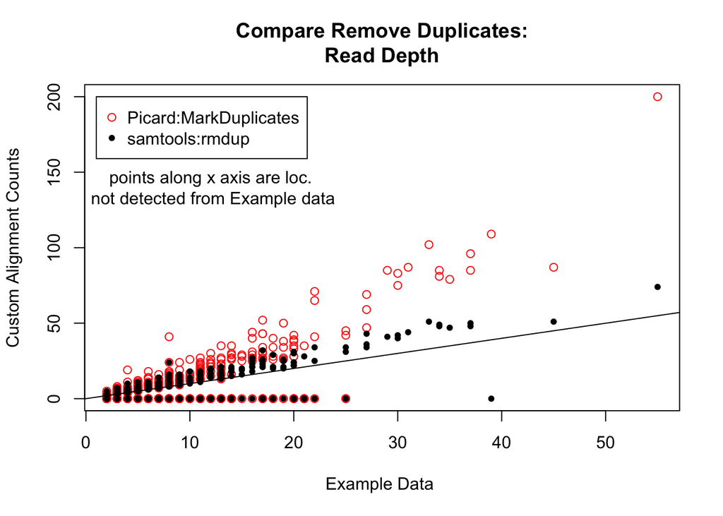

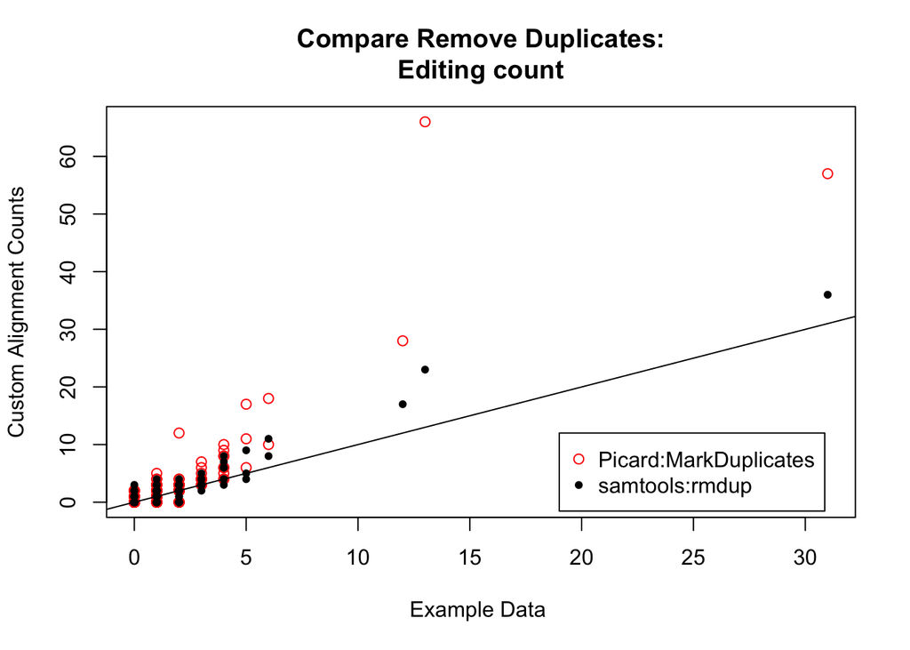

Samtools rmdup/Picard remvdup result in higher counts than counts supplied from paper.

## Variant caller

freebayes vs mpilup | bcftools

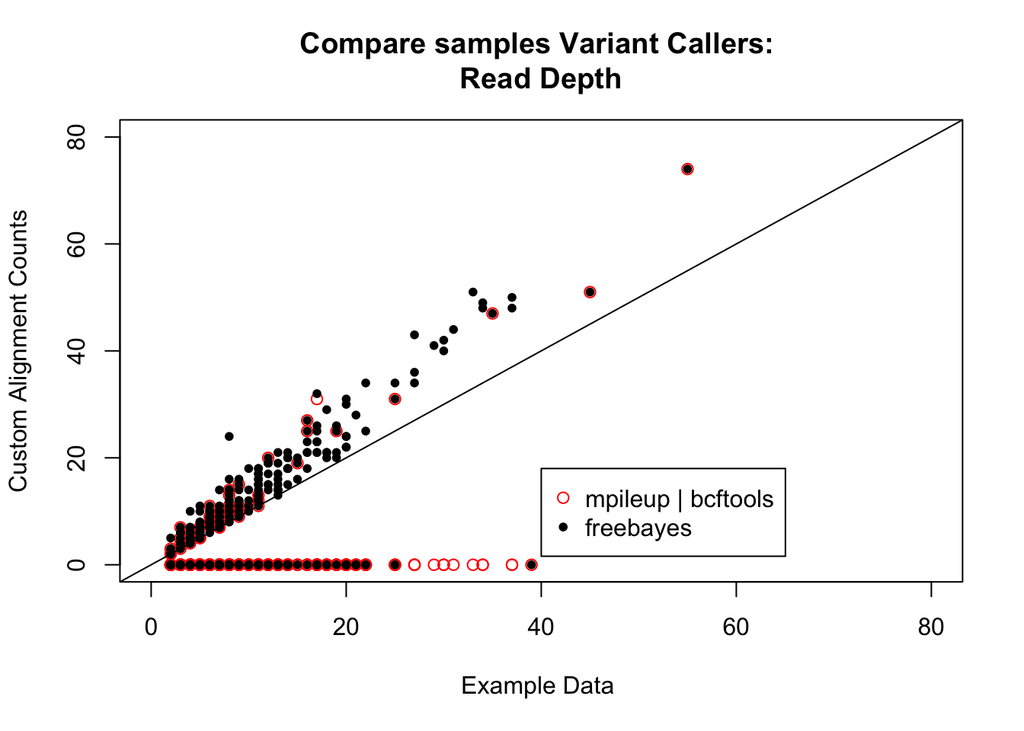

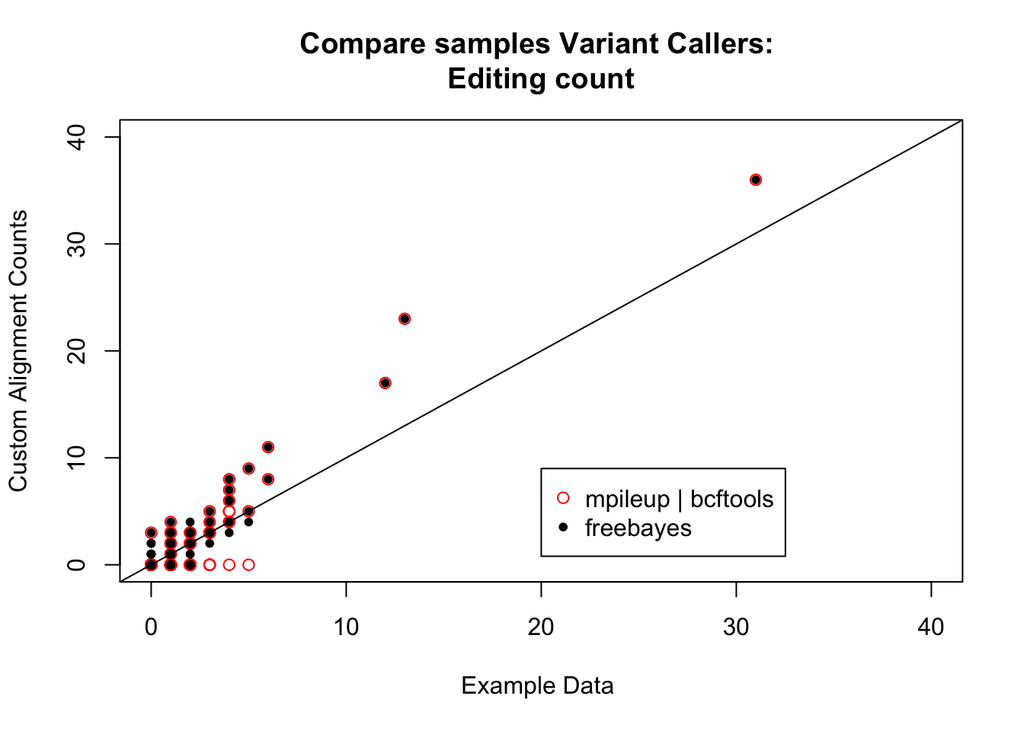

freebayes method identifies more of the variant positions than the mpileup | bcftools method.  
The counts for the positions that are identified are the same for both methods.

# Test counts filters after calling SNPs

**Compare Averaged data from both ADAR1 samples**

Given the list of possible RNAediting sites from chr2, determine how counts filters effect ability to reproduce data.  
Only call variants at sites identified from online data.

**Example data Editing sites:**  
Average Read depth > 0  
**Freebayes filter:**  
Variant read count > 1  
total read depth > 5  
variant frequency > 10%

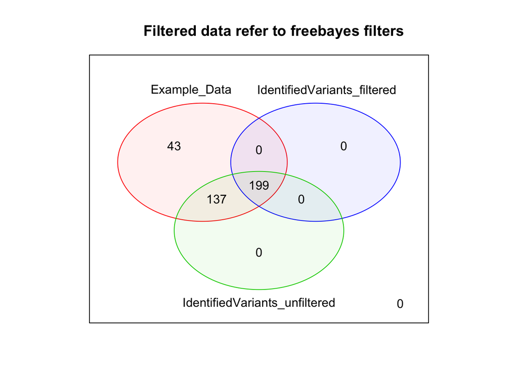

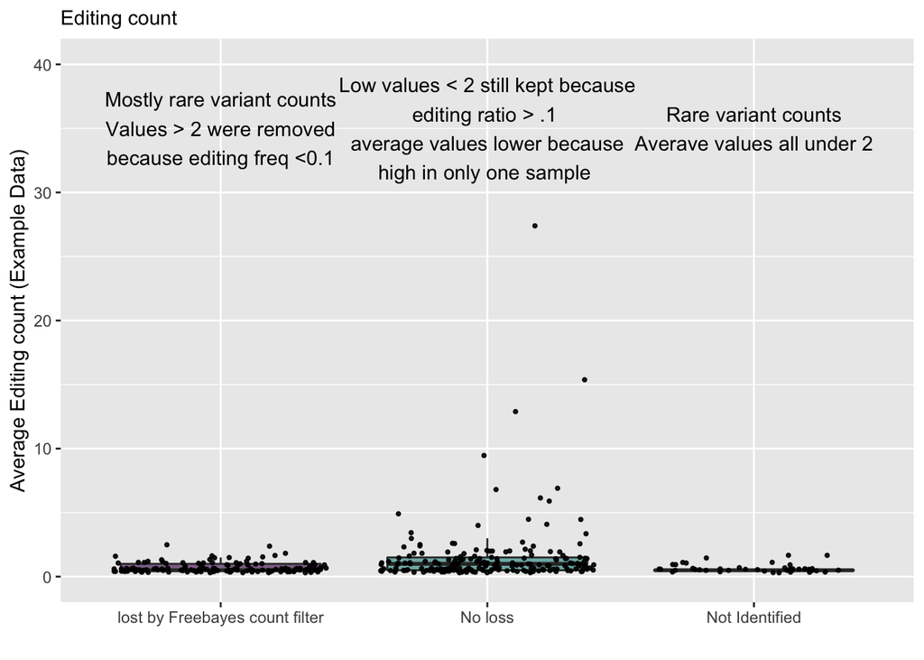

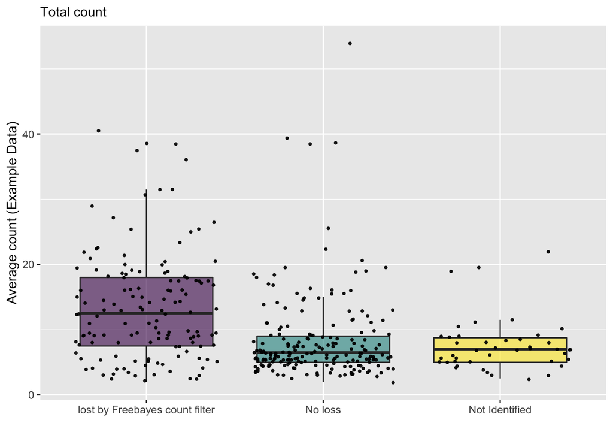

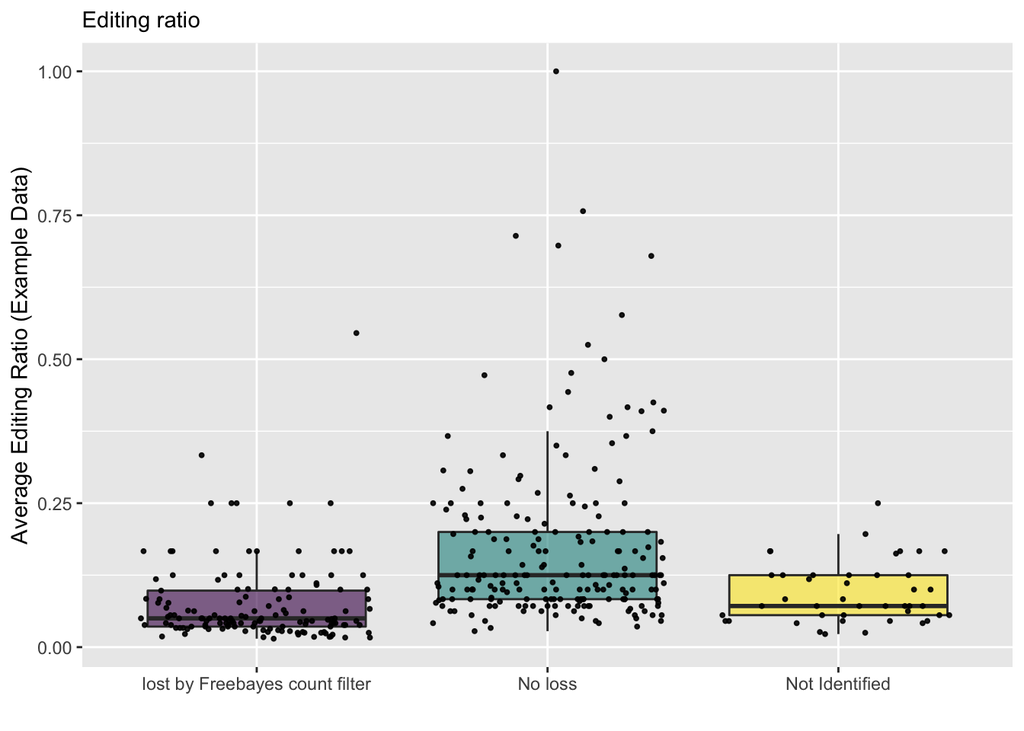

data_table: AverageExprssion_Exampledata_freebayescounts.txt

Missed Editing sites reflect the imposed filters when calling variants.  
Variants that were not detected have editing count less then 2 in online example.

The count filters remove rare editing sites that were detected in Example data.  
The biggest effect on our ability to count variants appears to be the remove duplicates procedure.

**Sample to Sample compairison**  
To simplify comparison going forward only compare counts for one sample.

Filter online sites by GIREMI criteria to ensure that remaining sites are most likely editing sites identified from ADAR1-sample1.

Criteria:  
Variant read count > 1  
total read depth > 5  
variant frequency > 10%

## Test SNV location filters

**“dbSNP” filter:** removes RDDs annotated as SNPs (dbSNP 135);  
**“homopolymer” filter:** removes sites in homopolyer runs of ≥5 bp;  
**“splice site” filter:** removes intronic RDDs within 4 bp of splice junctions;  
**“simple repeat” filter:** discards sites in simple repeats;

**Evaluate all positions in chr2**  
We will now call variants on entire datasets (not just those identified in example)

First check input and output for GIREMI.  
GIREMI should give RNA editing information for every variant in VCF.

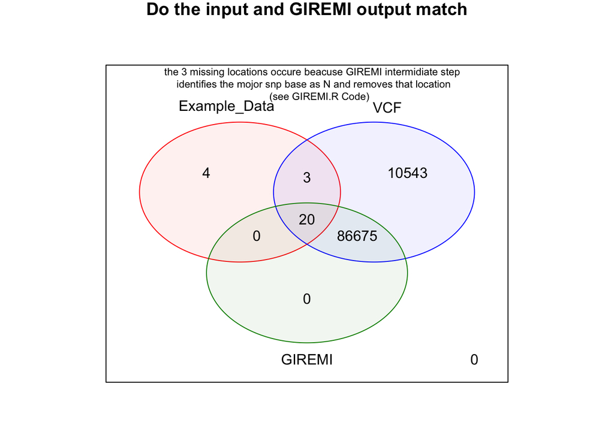

Sites removed by GIREMI:  
chr2:74375267  
chr2:91811384  
chr2:91811564

### Check “dbSNP” filter: removes RDDs annotated as SNPs (dbSNP 135)

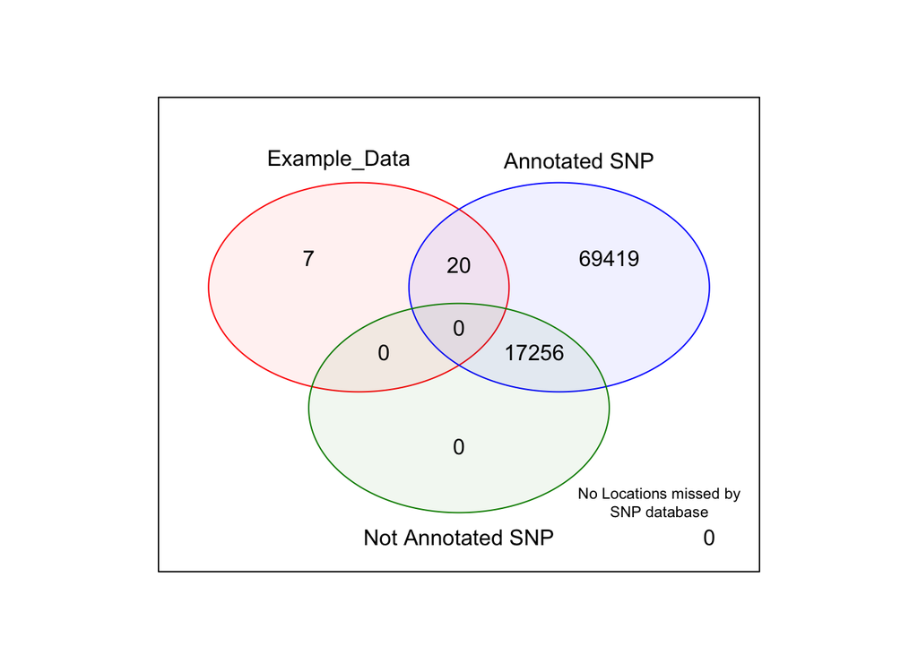

### “splice site” filter: removes intronic RDDs within 4 bp of splice junctions

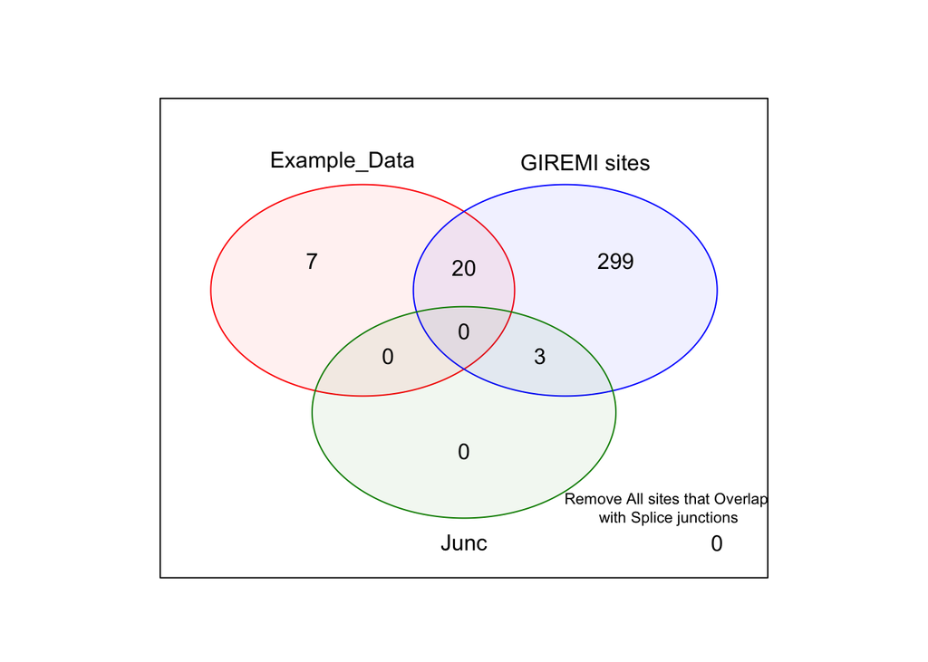

Sites removed by splice site filter:  
chr2:118853993  
chr2:44071743  
chr2:198361861

### “homopolymer” filter: removes sites in homopolyer runs of ≥5 bp

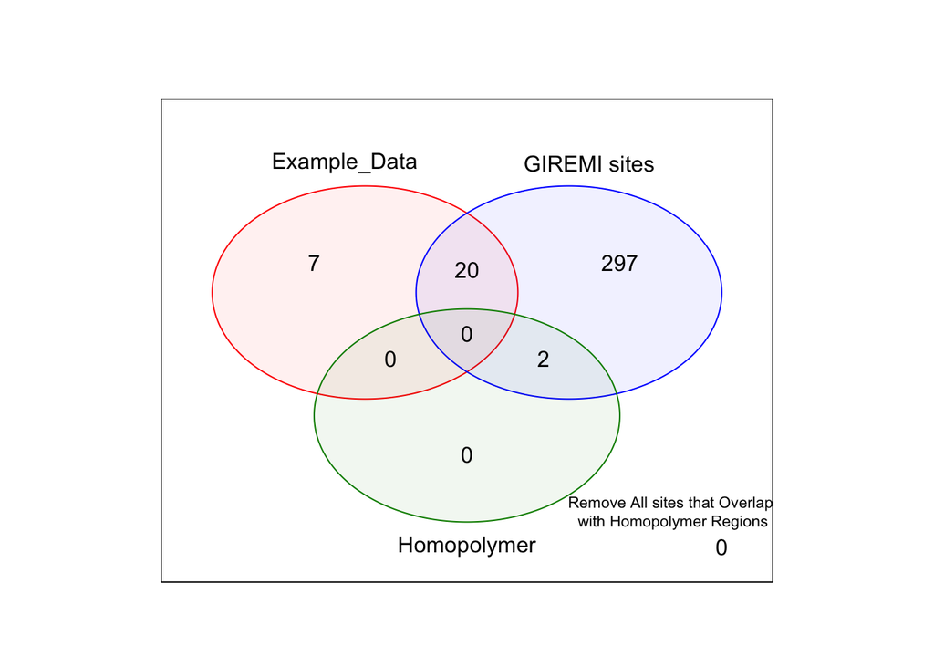

Sites removed by Homopolymer filter:  
chr2:71654450  
chr2:7181486

### “simple repeat” filter: discards sites in simple repeats

**Use locations from RepeatMasker**

Do not remove locations in Alu regions

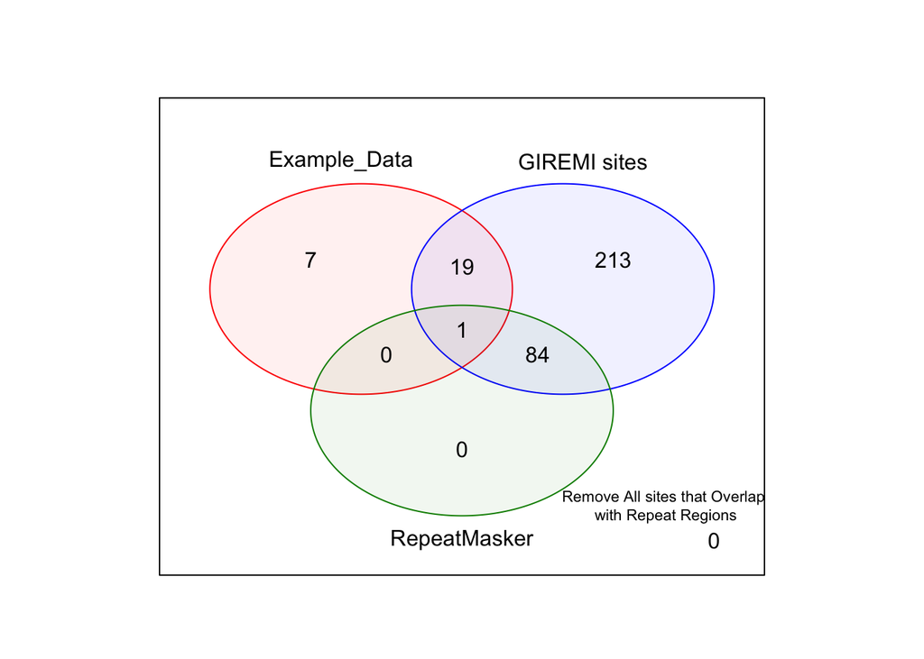

data_table: GIREMI_Output_RepeatMaskerFilter.txt

**Use locations from UCSC Repeats track**

Do not remove locations in Alu regions

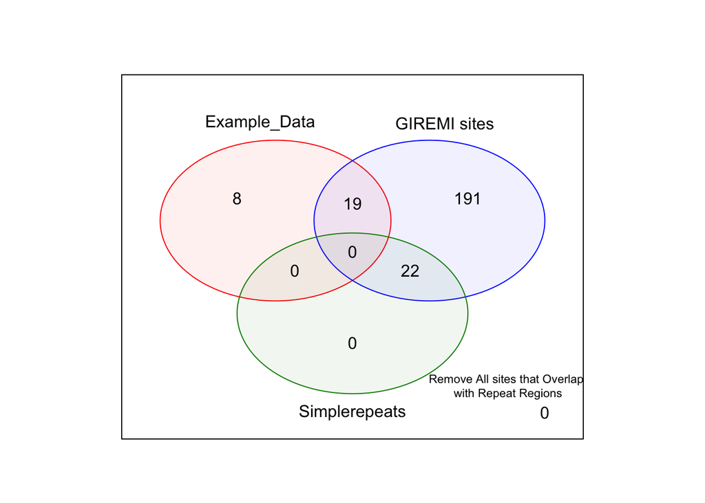

data_table: GIREMI_Output_RepeatMaskerFilter.txt

# Can we reproduce sites identified as RNA editing

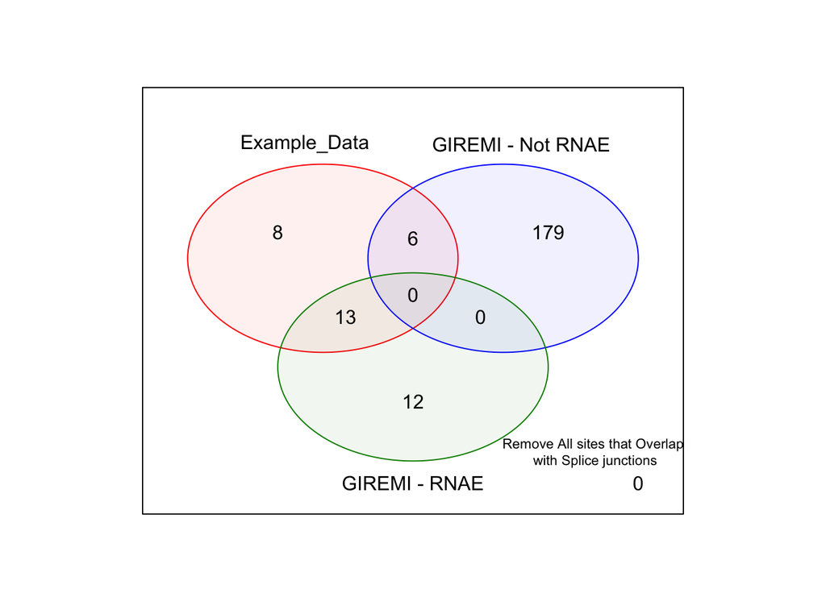

data_table: GIREMI_Output_afterAllFilter.txt

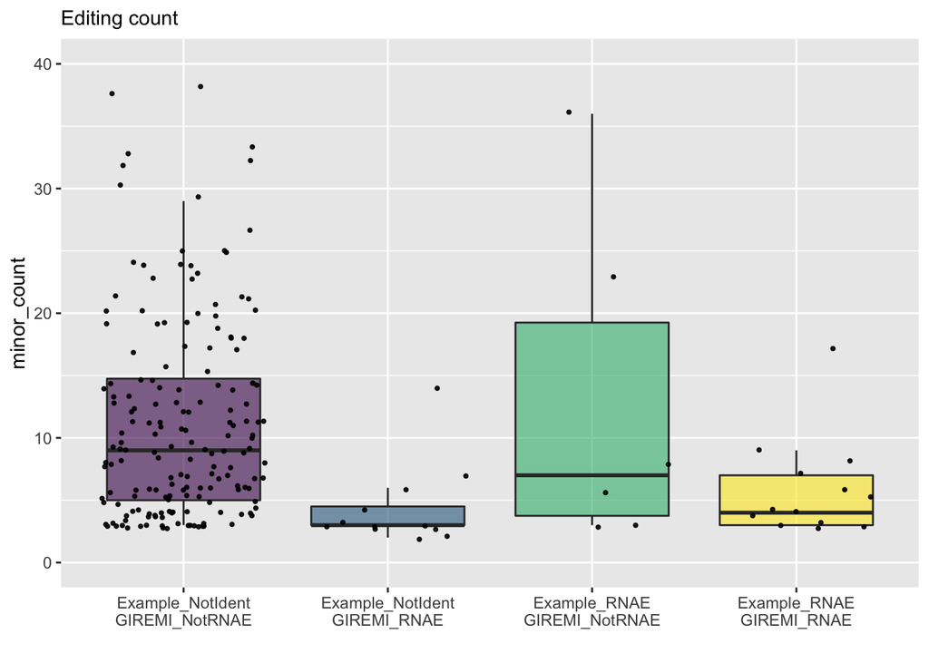

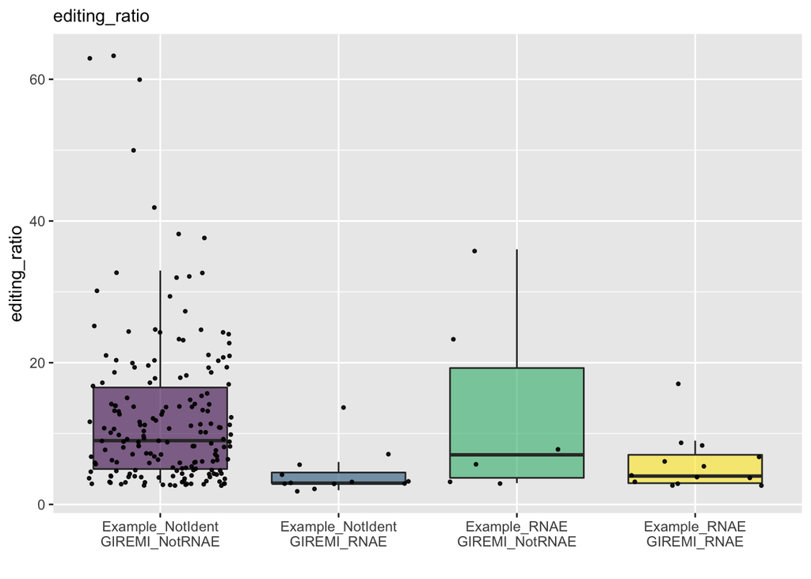

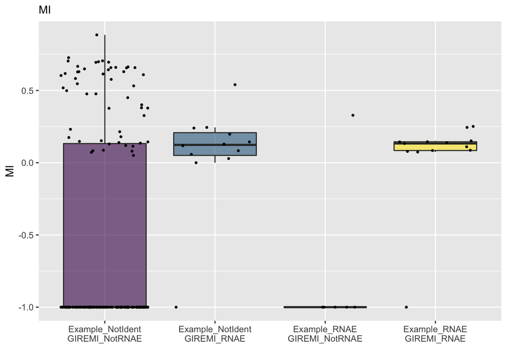

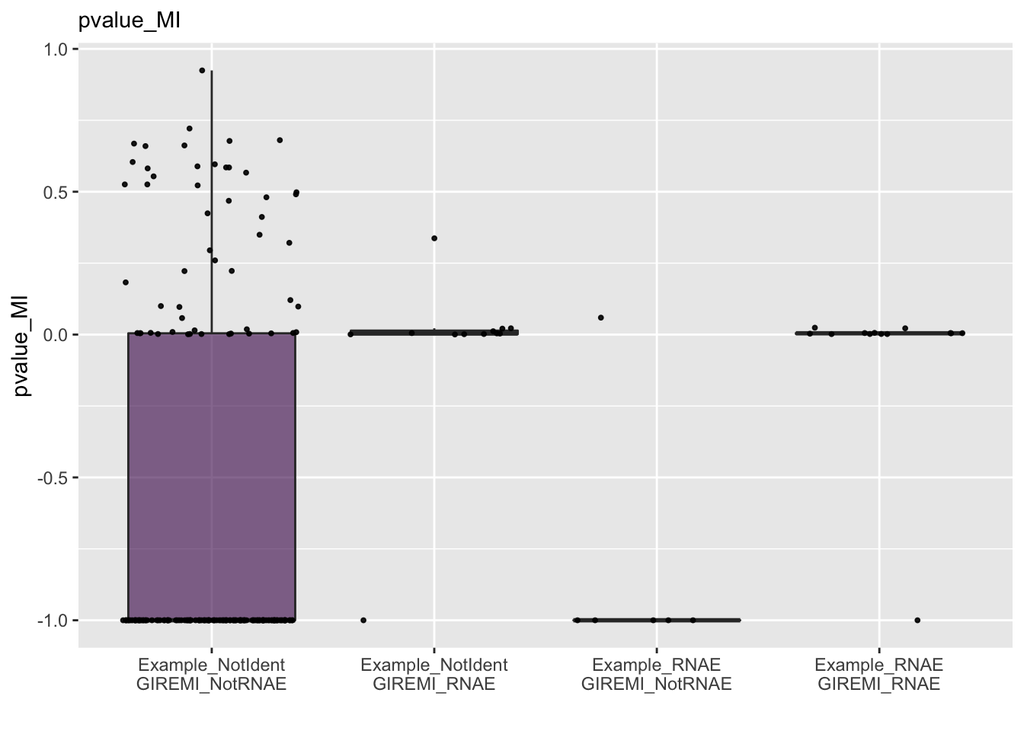

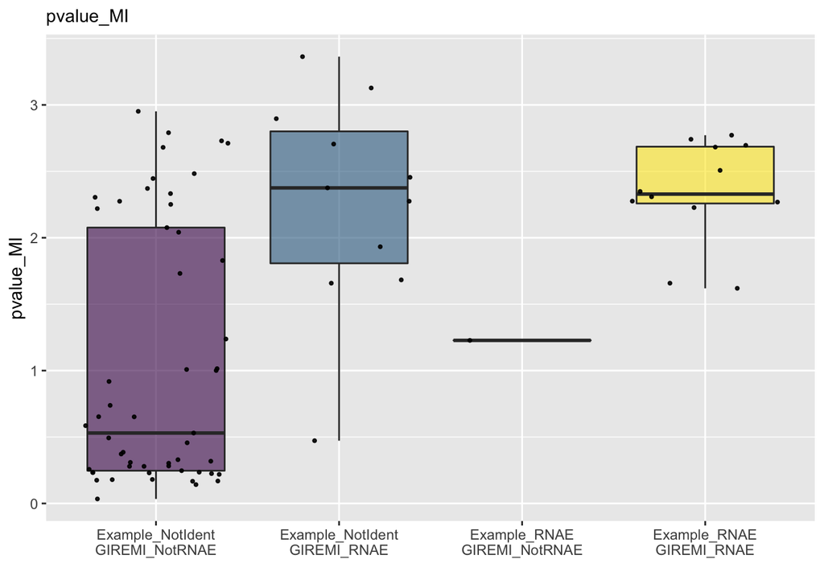